# Data Sprints - Technical test in Data Science

##### Candidato: Pablo Ernesto Vigneaux Wilton

##### (48) 99961-3266

## Minimum requirements

### 0.1 - Initialization of constants and data load

```python
import pandas as pd
import numpy as np
import pathlib
import sweetviz as sv
import geopandas as gpd
from shapely.geometry import Point, Polygon
import matplotlib.pyplot as plt


ROOT_DIR = pathlib.Path.cwd()

JSON_FILE_2009 = "data-sample_data-nyctaxi-trips-2009-json_corrigido.json"
JSON_FILE_2010 = "data-sample_data-nyctaxi-trips-2010-json_corrigido.json"
JSON_FILE_2011 = "data-sample_data-nyctaxi-trips-2011-json_corrigido.json"
JSON_FILE_2012 = "data-sample_data-nyctaxi-trips-2012-json_corrigido.json"

JSON_FILES = [ROOT_DIR / JSON_FILE_2009,
              ROOT_DIR / JSON_FILE_2010,
              ROOT_DIR / JSON_FILE_2011,
              ROOT_DIR / JSON_FILE_2012]

CSV_VENDORS = ROOT_DIR / "data-vendor_lookup-csv.csv"
NYC_MAP = ROOT_DIR / "Map/geo_export_0c8e2314-4c95-41f1-97cf-e65e88858c8c.shp"

data_frames = []
for file in JSON_FILES:
    data_frames.append(pd.read_json(file, lines=True))

big_data = pd.concat(data_frames)
```

### 0.2 - Exploratory Data Analysis (EDA)

#### 0.2.1 - Data structure and data types

This activity is necessary to understand the data

```python
big_data.info()
```

```
<class 'pandas.core.frame.DataFrame'>
Int64Index: 4000000 entries, 0 to 999999
Data columns (total 17 columns):
 #   Column              Dtype
---  ------              -----
 0   vendor_id           object
 1   pickup_datetime     object
 2   dropoff_datetime    object
 3   passenger_count     int64
 4   trip_distance       float64
 5   pickup_longitude    float64
 6   pickup_latitude     float64
 7   rate_code           float64
 8   store_and_fwd_flag  float64
 9   dropoff_longitude   float64
 10  dropoff_latitude    float64
 11  payment_type        object
 12  fare_amount         float64
 13  surcharge           float64
 14  tip_amount          float64
 15  tolls_amount        float64
 16  total_amount        float64
dtypes: float64(12), int64(1), object(4)
memory usage: 549.3+ MB
```

```python
print(f"Total of records loaded: {len(big_data.index)}")
```

```
Total of records loaded: 4000000
```

```python
big_data.head()
```

|  | vendor_id | pickup_datetime | dropoff_datetime | passenger_count | trip_distance | pickup_longitude | pickup_latitude | rate_code | store_and_fwd_flag | dropoff_longitude | dropoff_latitude | payment_type | fare_amount | surcharge | tip_amount | tolls_amount | total_amount |
| --- | --- | --- | --- | --- | --- | --- | --- | --- | --- | --- | --- | --- | --- | --- | --- | --- | --- |
| 0 | CMT | 2009-04-21T18:51:11.767205+00:00 | 2009-04-21T18:57:09.433767+00:00 | 2 | 0.80 | -74.004114 | 40.742950 | NaN | NaN | -73.994712 | 40.747950 | Cash | 5.4 | 0.0 | 0.0 | 0.0 | 5.4 |
| 1 | CMT | 2009-01-13T07:40:07.639754+00:00 | 2009-01-13T07:50:36.386011+00:00 | 1 | 5.40 | -73.996506 | 40.747784 | NaN | NaN | -73.940449 | 40.792385 | Cash | 15.4 | 0.0 | 0.0 | 0.0 | 15.4 |
| 2 | VTS | 2009-01-06T19:30:44.142187+00:00 | 2009-01-06T19:43:09.908429+00:00 | 5 | 1.67 | -73.951340 | 40.752070 | NaN | NaN | -73.944535 | 40.768108 | CASH | 6.1 | 1.0 | 0.0 | 0.0 | 7.1 |
| 3 | VTS | 2009-09-24T08:28:09.004451+00:00 | 2009-09-24T08:41:56.739991+00:00 | 1 | 4.13 | -74.001117 | 40.729128 | NaN | NaN | -73.958122 | 40.721812 | CASH | 12.9 | 0.5 | 0.0 | 0.0 | 13.4 |
| 4 | VTS | 2009-10-29T05:50:39.214629+00:00 | 2009-10-29T05:57:22.880174+00:00 | 1 | 2.03 | -73.976600 | 40.756873 | NaN | NaN | -73.979757 | 40.776075 | CASH | 7.7 | 0.5 | 0.0 | 0.0 | 8.2 |

#### 0.2.2 - Generating a better report on the data unsing Sweetviz

An HTML file, for each report, will be generated in the same directory as this Notebook. You can see others reports created with this lib inside "Reports" directory

```python
my_report = sv.analyze(big_data)
my_report.show_html("nyctaxi-trips-2009-2012-report.html")
```

```
:FEATURES DONE:                    |█████████████████████| [100%]   07:53  -> (00:00 left)
:PAIRWISE DONE:                    |█████████████████████| [100%]   02:14  -> (00:00 left)
```

[output not shown]

## Tasks' solutions

### 1) What is the average distance traveled by trips with a maximum of 2 passengers?

Getting the overall average

```python
print(f"Overall average: {big_data['trip_distance'].mean()}")
```

```
Overall average: 2.6782093030000023
```

Getting the averange for every number of passengers.

Obs.: We can see that there are trips with 0 passengers

```python
print(big_data.groupby("passenger_count")["trip_distance"].mean())
```

```
passenger_count
0    1.897297
1    2.614013
2    2.835128
3    2.788150
4    2.793984
5    2.721652
6    2.736686
Name: trip_distance, dtype: float64
```

Plotting the trips averange distance value for passenger

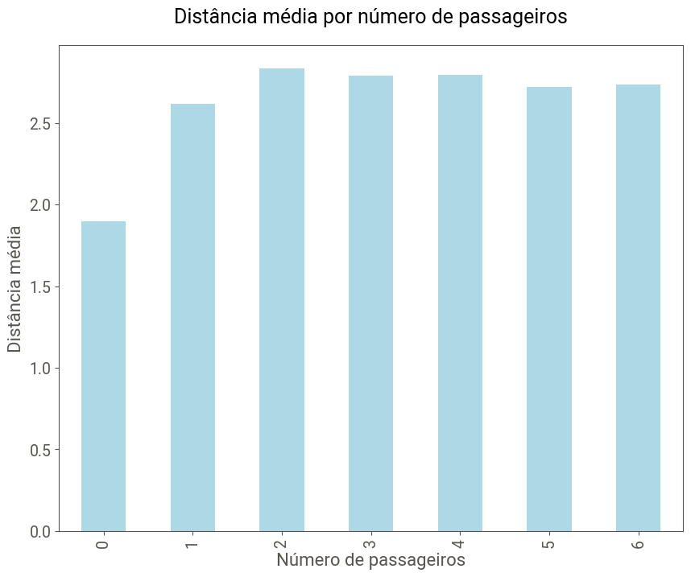

```python
distance_plot = big_data.groupby("passenger_count")["trip_distance"].mean().plot(kind="bar",
                                                                                 linewidth=2,
                                                                                 color="lightblue",
                                                                                 figsize=(10, 8),
                                                                                 fontsize=14)
distance_plot.set_xlabel("Número de passageiros", fontdict={'fontsize':16})
distance_plot.set_ylabel("Distância média", fontdict={'fontsize':16})
distance_plot.set_title("Distância média por número de passageiros", pad=20, fontdict={'fontsize':18})
```

### Solution 1: I will not consider trips with 0 passengers because this can be ruled out in some situations, such as travel distance statistics by number of passengers. The distance averange for trips with 1 or 2 passanger is:

```python
print(f'Average distance: {big_data.query("passenger_count > 0 and passenger_count <= 2")["trip_distance"].mean()}')
```

```
Average distance: 2.662629358569875
```

### Solution 2: I'll consider trips with 0 passengers because it can be considered in some situations like cost calc. The distance averange for trips with 0, 1 or 2 passanger is:

```python
print(f'Average distance : {big_data.query("passenger_count <= 2")["trip_distance"].mean()}')
```

```
Average distance : 2.6625269962032174
```

### 2) Which are the 3 biggest vendors based on the total amount of money raised?

Preparing data to take vendors names

Calculating and ordering the data

```python
amount_by_vendor = big_data.groupby("vendor_id")["total_amount"].sum().reset_index()
amount_by_vendor = amount_by_vendor.sort_values(by = ["total_amount"], ascending=[False], ignore_index=True)
print(amount_by_vendor.round(5))
```

```
  vendor_id  total_amount
0       CMT   19549084.28
1       VTS   19043434.00
2       DDS    2714901.72
3        TS         45.60
```

Join data to have vendors' names

```python
vendors_data = pd.read_csv(CSV_VENDORS)
amount_by_vendor = amount_by_vendor.merge(vendors_data, on="vendor_id", how="left")[["vendor_id", "name", "total_amount"]]
```

```python
print(amount_by_vendor.round(5))
```

```
  vendor_id                               name  total_amount
0       CMT  Creative Mobile Technologies, LLC   19549084.28
1       VTS                       VeriFone Inc   19043434.00
2       DDS     Dependable Driver Service, Inc    2714901.72
3        TS                 Total Solutions Co         45.60
```

Generating a general chart with all data

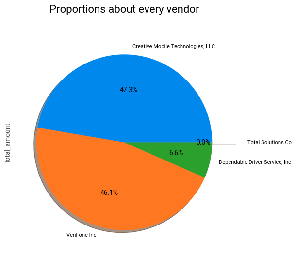

```python
amount_by_vendor_plot = amount_by_vendor.plot(kind="pie", y = "total_amount",
                                              labels=amount_by_vendor["name"],
                                              legend = False, autopct="%1.1f%%",
                                              figsize=(10, 6),
                                              explode=(0, 0, 0, 0.3),
                                              shadow=True,
                                              startangle=0)
amount_by_vendor_plot.set_title("Proportions about every vendor", pad=30, fontdict={'fontsize':16})
```

### Solution: These area the top 3 biggest vendors

```python
top_vendors = amount_by_vendor.iloc[:3].round(3)
print(top_vendors)
```

```
  vendor_id                               name  total_amount
0       CMT  Creative Mobile Technologies, LLC   19549084.28
1       VTS                       VeriFone Inc   19043434.00
2       DDS     Dependable Driver Service, Inc    2714901.72
```

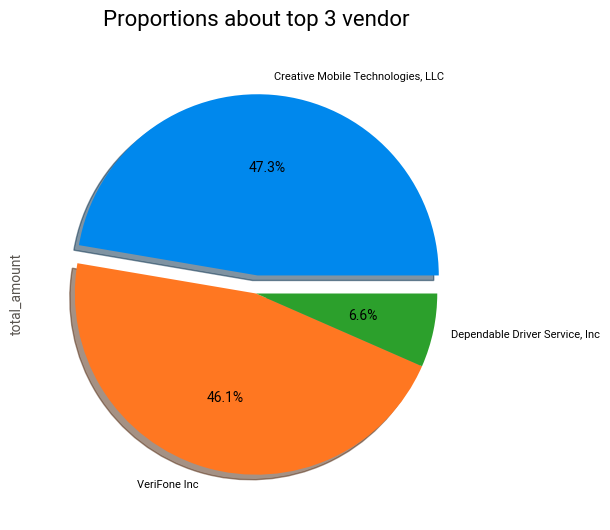

```python
top_vendors_plot = top_vendors.plot(kind="pie", y = "total_amount",
                                    labels=top_vendors["name"],
                                    legend=False,
                                    figsize=(10, 6),
                                    autopct="%1.1f%%",
                                    explode=(0.1, 0, 0),
                                    shadow=True,
                                    startangle=0)
top_vendors_plot.set_title("Proportions about top 3 vendor", pad=30, fontdict={'fontsize':16})
```

### 3) Make a histogram of the monthly distribution over 4 years of rides paid with cash.

Adjusting date types

```python
big_data["pickup_datetime"] = pd.to_datetime(big_data["pickup_datetime"])
big_data["dropoff_datetime"] = pd.to_datetime(big_data["dropoff_datetime"])
```

Data Evalating

```python
big_data.head(10)
```

|  | vendor_id | pickup_datetime | dropoff_datetime | passenger_count | trip_distance | pickup_longitude | pickup_latitude | rate_code | store_and_fwd_flag | dropoff_longitude | dropoff_latitude | payment_type | fare_amount | surcharge | tip_amount | tolls_amount | total_amount |
| --- | --- | --- | --- | --- | --- | --- | --- | --- | --- | --- | --- | --- | --- | --- | --- | --- | --- |
| 0 | CMT | 2009-04-21 18:51:11.767205+00:00 | 2009-04-21 18:57:09.433767+00:00 | 2 | 0.80 | -74.004114 | 40.742950 | NaN | NaN | -73.994712 | 40.747950 | Cash | 5.4 | 0.0 | 0.0 | 0.00 | 5.40 |
| 1 | CMT | 2009-01-13 07:40:07.639754+00:00 | 2009-01-13 07:50:36.386011+00:00 | 1 | 5.40 | -73.996506 | 40.747784 | NaN | NaN | -73.940449 | 40.792385 | Cash | 15.4 | 0.0 | 0.0 | 0.00 | 15.40 |
| 2 | VTS | 2009-01-06 19:30:44.142187+00:00 | 2009-01-06 19:43:09.908429+00:00 | 5 | 1.67 | -73.951340 | 40.752070 | NaN | NaN | -73.944535 | 40.768108 | CASH | 6.1 | 1.0 | 0.0 | 0.00 | 7.10 |
| 3 | VTS | 2009-09-24 08:28:09.004451+00:00 | 2009-09-24 08:41:56.739991+00:00 | 1 | 4.13 | -74.001117 | 40.729128 | NaN | NaN | -73.958122 | 40.721812 | CASH | 12.9 | 0.5 | 0.0 | 0.00 | 13.40 |
| 4 | VTS | 2009-10-29 05:50:39.214629+00:00 | 2009-10-29 05:57:22.880174+00:00 | 1 | 2.03 | -73.976600 | 40.756873 | NaN | NaN | -73.979757 | 40.776075 | CASH | 7.7 | 0.5 | 0.0 | 0.00 | 8.20 |
| 5 | VTS | 2009-10-23 17:14:45.661393+00:00 | 2009-10-23 17:23:51.913687+00:00 | 1 | 1.15 | -73.994665 | 40.750528 | NaN | NaN | -73.978623 | 40.750478 | CASH | 6.5 | 0.0 | 0.0 | 0.00 | 6.50 |
| 6 | VTS | 2009-03-30 09:41:23.359373+00:00 | 2009-03-30 09:47:12.908395+00:00 | 1 | 8.61 | -73.955462 | 40.772843 | NaN | NaN | -73.870838 | 40.774042 | CASH | 22.1 | 0.0 | 0.0 | 4.15 | 26.25 |
| 7 | VTS | 2009-03-18 17:56:30.217996+00:00 | 2009-03-18 18:02:40.735727+00:00 | 5 | 0.84 | -73.976158 | 40.757998 | NaN | NaN | -73.985112 | 40.759317 | Credit | 5.7 | 0.0 | 2.0 | 0.00 | 7.70 |
| 8 | VTS | 2009-03-30 13:21:23.577454+00:00 | 2009-03-30 13:32:11.850561+00:00 | 2 | 1.04 | -73.988585 | 40.764408 | NaN | NaN | -73.975072 | 40.761585 | CASH | 6.1 | 0.0 | 0.0 | 0.00 | 6.10 |
| 9 | VTS | 2009-02-20 18:06:37.232527+00:00 | 2009-02-20 18:11:48.973565+00:00 | 5 | 0.75 | -74.001978 | 40.740683 | NaN | NaN | -73.993722 | 40.747330 | CASH | 3.7 | 0.0 | 0.0 | 0.00 | 3.70 |

Get used payment types

```python
big_data["payment_type"].unique()
```

```
array(['Cash', 'CASH', 'Credit', 'CREDIT', 'No Charge', 'Dispute'],
      dtype=object)
```

Calculate monthly distribution for cash payments

```python
cash_only = big_data.query("payment_type in ('Cash', 'CASH')")
trips_monthly_distribution = cash_only["pickup_datetime"].groupby(cash_only.pickup_datetime.dt.to_period("M")).agg('count')
cash_monthly_distribution = cash_only.groupby(cash_only.pickup_datetime.dt.to_period("M"))["total_amount"].agg("sum")
```

Checking some data just to be aware

```python
trips_monthly_distribution.head()
```

```
pickup_datetime
2009-01    66824
2009-02    66680
2009-03    73948
2009-04    71142
2009-05    74151
Freq: M, Name: pickup_datetime, dtype: int64
```

```python
cash_monthly_distribution.head()
```

```
pickup_datetime
2009-01    627267.13
2009-02    625186.60
2009-03    696467.42
2009-04    667394.58
2009-05    698388.04
Freq: M, Name: total_amount, dtype: float64
```

```python
# Valor médio pago em dinheiro
cash_only.groupby(cash_only.pickup_datetime.dt.to_period("M"))["total_amount"].agg("mean")
```

```
pickup_datetime
2009-01    9.386854
2009-02    9.375924
2009-03    9.418340
2009-04    9.381161
2009-05    9.418457
2009-06    9.383427
2009-07    9.417560
2009-08    9.418126
2009-09    9.393466
2009-10    9.395865
2009-11    9.382739
2009-12    9.469365
2010-01    9.403851
2010-02    9.349464
2010-03    9.440984
2010-04    9.449086
2010-05    9.374283
2010-06    9.440984
2010-07    9.399963
2010-08    9.382390
2010-09    9.351368
2010-10    9.405545
2010-11    9.399080
2010-12    9.394733
2011-01    9.373249
2011-02    9.404944
2011-03    9.385842
2011-04    9.390212
2011-05    9.376964
2011-06    9.396634
2011-07    9.411994
2011-08    9.459216
2011-09    9.381917
2011-10    9.421700
2011-11    9.383597
2012-01    9.388085
2012-02    9.369674
2012-03    9.399258
2012-04    9.397881
2012-05    9.406338
2012-06    9.405863
2012-07    9.373794
2012-08    9.413431
2012-09    9.430646
2012-10    9.414073
Freq: M, Name: total_amount, dtype: float64
```

Recreating as Dataframes

```python
trips_monthly_distribution = pd.DataFrame({"monthly":trips_monthly_distribution.index, "trips":trips_monthly_distribution.values})
cash_monthly_distribution = pd.DataFrame({"monthly":cash_monthly_distribution.index, "cash":cash_monthly_distribution.values})
```

```python
print(cash_monthly_distribution)
```

```
    monthly       cash
0   2009-01  627267.13
1   2009-02  625186.60
2   2009-03  696467.42
3   2009-04  667394.58
4   2009-05  698388.04
5   2009-06  669432.45
6   2009-07  697615.20
7   2009-08  697139.14
8   2009-09  671736.14
9   2009-10  695397.38
10  2009-11  670152.72
11  2009-12  204377.30
12  2010-01  622337.46
13  2010-02  624890.13
```

[output cut: 31 more lines]

### Solution: Histogram of the monthly distribution over 4 years of rides paid with cash

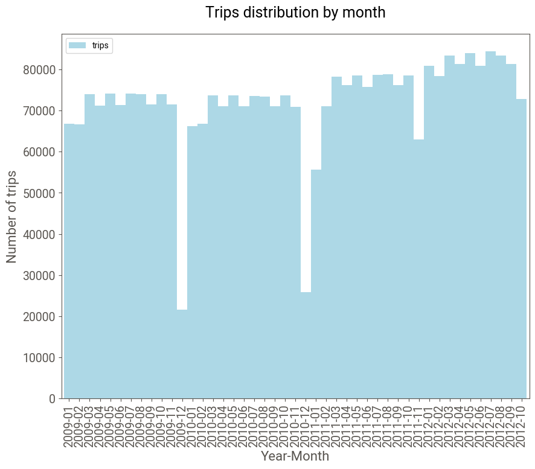

```python
trip_distribution_plot = trips_monthly_distribution.plot(kind="bar",
                                                         x="monthly",
                                                         width=1.0,
                                                         linewidth=2,
                                                         color="lightblue",
                                                         figsize=(10, 8),
                                                         fontsize=14,
                                                         rot=90)
trip_distribution_plot.set_xlabel("Year-Month", fontdict={'fontsize':16})
trip_distribution_plot.set_ylabel("Number of trips", fontdict={'fontsize':16})
trip_distribution_plot.set_title("Trips distribution by month", pad=20, fontdict={'fontsize':18})
```

The histogram below is just to confirm that the monetary value has the same behavior as the number of trips

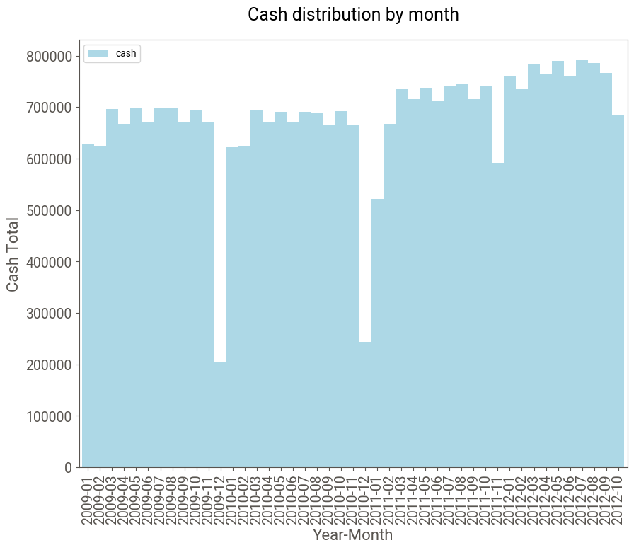

```python
cash_distribution_plot = cash_monthly_distribution.plot(kind="bar",
                                                        x="monthly",
                                                        width=1.0,
                                                        linewidth=2,
                                                        color="lightblue",
                                                        figsize=(10, 8),
                                                        fontsize=14,
                                                        rot=90)
cash_distribution_plot.set_xlabel("Year-Month", fontdict={'fontsize':16})
cash_distribution_plot.set_ylabel("Cash Total", fontdict={'fontsize':16})
cash_distribution_plot.set_title("Cash distribution by month", pad=20, fontdict={'fontsize':18})
```

### 4) Make a time series chart computing the number of tips each day for the last 3 months of 2012.

Data preparation

```python
last_months_2012 = big_data[big_data["pickup_datetime"].dt.year == 2012] #["pickup_datetime"]
```

Data visualization just for quick analysis

```python
last_months_2012.head()
```

|  | vendor_id | pickup_datetime | dropoff_datetime | passenger_count | trip_distance | pickup_longitude | pickup_latitude | rate_code | store_and_fwd_flag | dropoff_longitude | dropoff_latitude | payment_type | fare_amount | surcharge | tip_amount | tolls_amount | total_amount |
| --- | --- | --- | --- | --- | --- | --- | --- | --- | --- | --- | --- | --- | --- | --- | --- | --- | --- |
| 0 | CMT | 2012-06-09 16:21:13.580003+00:00 | 2012-06-09 16:31:19.862787+00:00 | 2 | 0.80 | -74.004114 | 40.742950 | NaN | NaN | -73.994712 | 40.747950 | Cash | 5.4 | 0.0 | 0.0 | 0.0 | 5.4 |
| 1 | CMT | 2012-08-14 21:44:14.940659+00:00 | 2012-08-14 21:54:50.018630+00:00 | 1 | 5.40 | -73.996506 | 40.747784 | NaN | NaN | -73.940449 | 40.792385 | Cash | 15.4 | 0.0 | 0.0 | 0.0 | 15.4 |
| 2 | VTS | 2012-07-06 17:12:07.862531+00:00 | 2012-07-06 17:22:57.404442+00:00 | 5 | 1.67 | -73.951340 | 40.752070 | NaN | NaN | -73.944535 | 40.768108 | CASH | 6.1 | 1.0 | 0.0 | 0.0 | 7.1 |
| 3 | VTS | 2012-07-22 04:12:28.704958+00:00 | 2012-07-22 04:20:45.142945+00:00 | 1 | 4.13 | -74.001117 | 40.729128 | NaN | NaN | -73.958122 | 40.721812 | CASH | 12.9 | 0.5 | 0.0 | 0.0 | 13.4 |
| 4 | VTS | 2012-07-11 11:40:13.774610+00:00 | 2012-07-11 11:49:03.034108+00:00 | 1 | 2.03 | -73.976600 | 40.756873 | NaN | NaN | -73.979757 | 40.776075 | CASH | 7.7 | 0.5 | 0.0 | 0.0 | 8.2 |

Adjusting and calculating data by day

```python
last_months_2012 = last_months_2012['pickup_datetime'].groupby(last_months_2012.pickup_datetime.dt.to_period("D")).agg('count')
last_months_2012 = pd.DataFrame({"daily_2012":last_months_2012.index, "trips":last_months_2012.values})
```

```python
last_months_2012.head()
```

|  | daily_2012 | trips |
| --- | --- | --- |
| 0 | 2012-01-02 | 3373 |
| 1 | 2012-01-03 | 3252 |
| 2 | 2012-01-04 | 3278 |
| 3 | 2012-01-05 | 3270 |
| 4 | 2012-01-06 | 3336 |

Preparing data to be ploted

```python
last_months_2012["daily_2012"] = last_months_2012["daily_2012"].dt.to_timestamp('s').dt.strftime('%Y-%m-%d %H:%M:%S.000')
last_months_2012["daily_2012"] = pd.to_datetime(last_months_2012["daily_2012"])
last_months_2012 = last_months_2012.set_index("daily_2012")
last_months_2012 = last_months_2012.last("3M")
```

```python
last_months_2012.head(300)
```

| daily_2012 | trips |
| --- | --- |
| 2012-08-01 | 3292 |
| 2012-08-02 | 3306 |
| 2012-08-03 | 3450 |
| 2012-08-04 | 3282 |
| 2012-08-05 | 3273 |
| ... | ... |
| 2012-10-23 | 3372 |
| 2012-10-24 | 3401 |
| 2012-10-25 | 3245 |
| 2012-10-26 | 3371 |
| 2012-10-27 | 3297 |

88 rows × 1 columns

### Solution: Time series chart computing the number of tips each day for the last 3 months of 2012.

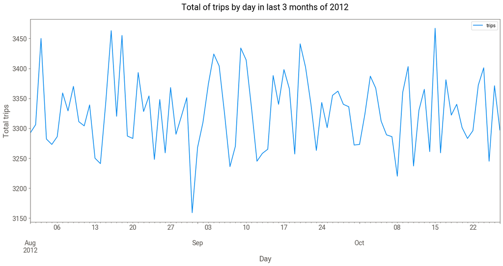

```python
last_months_2012_plot = last_months_2012.plot(figsize=(18, 8),
                                              fontsize=14)
last_months_2012_plot.set_xlabel("Day", fontdict={'fontsize':16})
last_months_2012_plot.set_ylabel("Total trips", fontdict={'fontsize':16})
last_months_2012_plot.set_title("Total of trips by day in last 3 months of 2012", pad=20, fontdict={'fontsize':18})
```

## Bonus items

### 1) What is the average trip time on Saturdays and Sundays?

Data preparing - Getting day of week names

```python
day_of_week = pd.DataFrame({"pickup_datetime":big_data["pickup_datetime"],
                            "day_of_week": big_data["pickup_datetime"].dt.day_name(),
                            "trip_time_minutes": ((big_data.dropoff_datetime - big_data.pickup_datetime).dt.seconds/60).round(2)})
```

```python
day_of_week.head()
```

|  | pickup_datetime | day_of_week | trip_time_minutes |
| --- | --- | --- | --- |
| 0 | 2009-04-21 18:51:11.767205+00:00 | Tuesday | 5.95 |
| 1 | 2009-01-13 07:40:07.639754+00:00 | Tuesday | 10.47 |
| 2 | 2009-01-06 19:30:44.142187+00:00 | Tuesday | 12.42 |
| 3 | 2009-09-24 08:28:09.004451+00:00 | Thursday | 13.78 |
| 4 | 2009-10-29 05:50:39.214629+00:00 | Thursday | 6.72 |

```python
weekends_trips = day_of_week.query("day_of_week in ('Saturday', 'Sunday')")
```

### Solution: The average trip time (in minutes) on Saturdays and Sundays.

```python
print(weekends_trips.groupby("day_of_week").agg(["sum", "count", "mean"]))
```

```
            trip_time_minutes
                          sum   count      mean
day_of_week
Saturday           4962975.51  567803  8.740664
Sunday             4934526.52  564871  8.735670
```

### 2) Analyse the data to find and prove seasonality

Not done

### 3) Create assumptions, validate against a data and prove with storyelling and graphs

Not done

### 4) Find what the fare amount (inclusive of tolls) for a taxi ride in New York City given the pickup and dropoff locations

Not done

### 5) Make a latitude and longitude map view of pickups and dropoffs in the year 2010

Load map data of NYC

```python
nyc_street_map = gpd.read_file(NYC_MAP)
```

Defines the coordinate system to be used

```python
nyc_shape = nyc_street_map.to_crs({'init': 'epsg:4326'})
```

Show NYC shape map

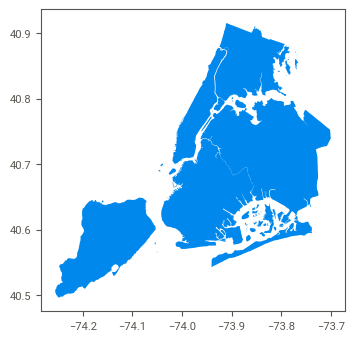

```python
nyc_shape.plot()
```

Show coordinates bounds

```python
nyc_shape.total_bounds
```

```
array([-74.25559136,  40.4961154 , -73.70000906,  40.91553278])
```

Prepare data to be plotted

```python
crs = {'init': 'epsg:4326'} #{"init":"espc:4326"} #(latitude, longitude)

small_data = big_data[["pickup_longitude", "pickup_latitude", "dropoff_longitude", "dropoff_latitude"]].copy()
small_data["action"] = 1

small_data.head()
```

|  | pickup_longitude | pickup_latitude | dropoff_longitude | dropoff_latitude | action |
| --- | --- | --- | --- | --- | --- |
| 0 | -74.004114 | 40.742950 | -73.994712 | 40.747950 | 1 |
| 1 | -73.996506 | 40.747784 | -73.940449 | 40.792385 | 1 |
| 2 | -73.951340 | 40.752070 | -73.944535 | 40.768108 | 1 |
| 3 | -74.001117 | 40.729128 | -73.958122 | 40.721812 | 1 |
| 4 | -73.976600 | 40.756873 | -73.979757 | 40.776075 | 1 |

```python
pickups_data_geometry = [Point(coordinates) for coordinates in zip(small_data["pickup_longitude"], small_data["pickup_latitude"])]
geo_small_data = gpd.GeoDataFrame(small_data, crs=crs, geometry=pickups_data_geometry)
```

#### Taxi pickups map

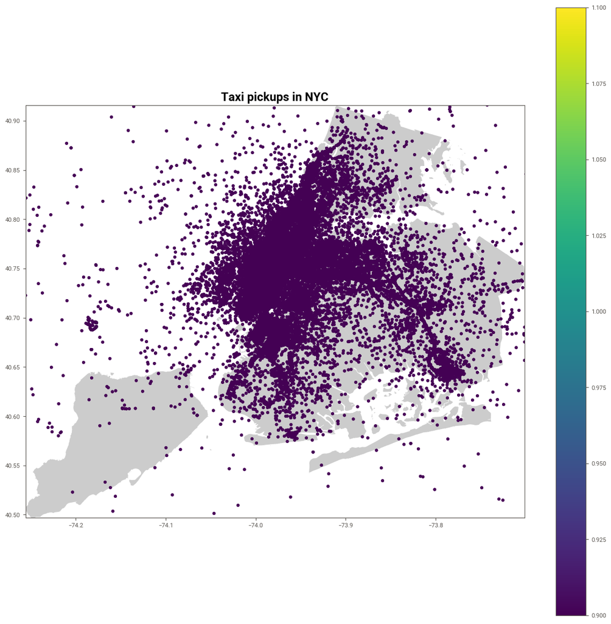

```python
nyc_figure, nyc_axes = plt.subplots(figsize=(15,15))
nyc_street_map.plot(ax=nyc_axes, alpha=0.4, color="grey")
geo_small_data.plot(column="action", ax=nyc_axes, markersize=10, alpha=0.5, legend=True)
plt.title("Taxi pickups in NYC", fontsize=16, fontweight="bold")
plt.xlim(-74.256, -73.701)
plt.ylim(40.497, 40.916)
plt.show()
```

```python
dropoff_data_geometry = [Point(coordinates) for coordinates in zip(small_data["dropoff_longitude"], small_data["dropoff_latitude"])]
geo_small_data = gpd.GeoDataFrame(small_data, crs=crs, geometry=dropoff_data_geometry)
```

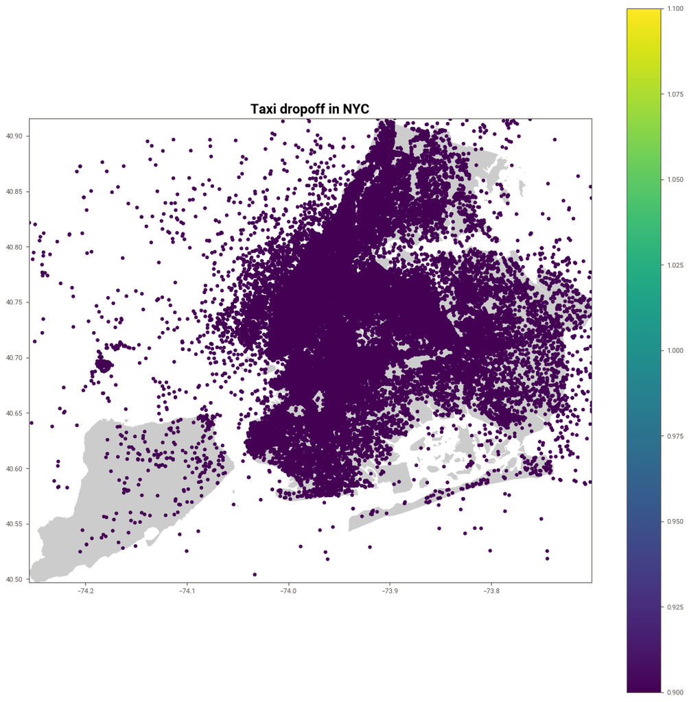

```python
nyc_figure, nyc_axes = plt.subplots(figsize=(15,15))
nyc_street_map.plot(ax=nyc_axes, alpha=0.4, color="grey")
geo_small_data.plot(column="action", ax=nyc_axes, markersize=10, alpha=0.5, legend=True)
plt.title("Taxi dropoff in NYC", fontsize=16, fontweight="bold")
plt.xlim(-74.256, -73.701)
plt.ylim(40.497, 40.916)
plt.show()
```

#### Obs.: We can see many points plotted in the wrong places like the sea. Possibly this is due to an error in the GPS, a link follows regarding the reduction of this error over the years. Nowadays the error still exists, but it needs a better analysis including GPS error data.

- https://www.gps.gov/governance/advisory/meetings/2014-06/bailey.pdf
- http://ravtrack.com/GPStracking/gps-position-accuracy/

#### Obs.2: There are missing months:

#### - December 2011

#### - November 2012

#### - December 2012

#### Because of the inability to create new data using inference, all analyzes simply did not consider it. Theorizing that there is a significant increase in taxi travel, much greater than that shown in the analyzes, but complete data would be needed for this, including population growth.